# Time Series Decomposition

September 5, 2017

## Background

Time series can exhibit variety of patterns, which can be split into components representing different patterns

Extracting patterns & components yields two benefits:

- Understand series better
- Improve forecasts

## Time Series Patterns

Three types of patterns:

1. **Trend:** long-term increase or decrease in data
   - May change direction
2. **Seasonal:** influenced by seasonal factors
   - Always of fixed, known period
3. **Cyclic:** rises and falls *not* of fixed period

## Time Series Patterns

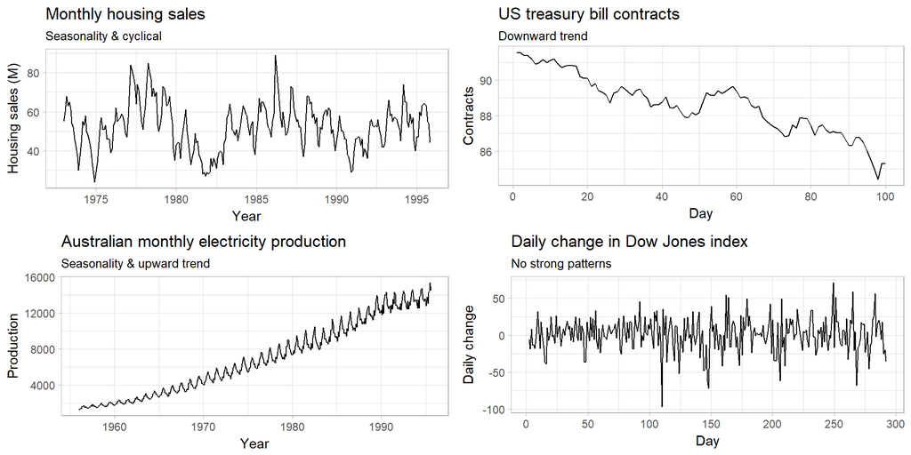

## Time Series Components

A series \(y_t\) has 3 components:

- seasonal component \(S_t\) (fixed-period variation)
- trend-cycle component \(T_t\) (long-term trend & non-fixed cycle)
- remainder component \(E_t\) (anything else in time series)

**Additive Model:** \[y_t = S_t + T_t + E_t\]

Seasonal fluctuation magnitude & trend-cycle variation are not proportional to level of time series

**Multiplicative Model:** \[y_t = S_t \times T_t \times E_t\]

Seasonal fluctuation magnitude & trend-cycle variation varies with level

*Transformed:* \(\log y_t = \log S_t + \log T_t + \log E_t\)

## Seasonally Adjusted Data

The data with the seasonal component removed (\(y_t - S_t\) or \(y_t / S_t\)) is the **seasonally adjusted data**.

- Useful if seasonal variation is not pattern of interest
- Comprises remainder and trend-cycle components
- Commonly used for economic data to study non-seasonal variation

## Moving Averages

Moving average of order \(m\) (\(m\)-MA): \[\hat{T}_t = \frac{1}{m} \sum_{j = -k}^k y_{t+j}\]

- Averages values \(y_j\) within \(k\) periods of \(t\)
- Eliminates some randomness, estimating trend-cycle
- Captures trend without minor fluctuation
- Increasing order increases smoothness

## Moving Averages

### MA Order

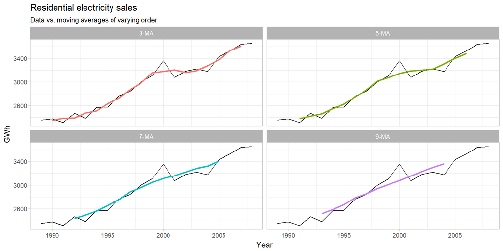

## Moving Averages

### Averages of Averages

- The moving average of a moving average gives a smoother trend estimate
- Even-order MA of even-order MA will return a symmetric MA
  - *i.e.* takes same number of points before and after \(t\)
- Notation \(m_2 \times m_1\)-MA

### Estimating Trend with Seasonal Data

Taking \(2 \times m\)-MA yields weighted MA of period \(m+1\) with first and last observations having half-weight. This can be used to view the trend absent seasonality

## Moving Averages

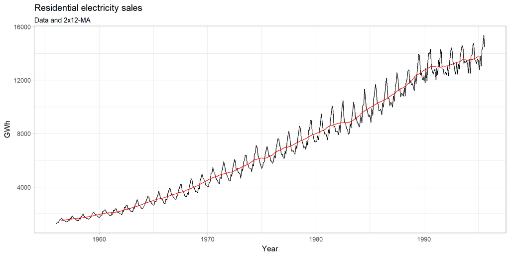

## Classical Decomposition

**Additive decomposition:**

1. Compute trend cycle component \(\hat{T}_t\)
   - \(2 \times m\)-MA if \(m\) is even
   - \(m\)-MA if \(m\) is odd
2. Calculate de-trended series \(y_t - \hat{T}_t\)
3. Calculate \(\hat{S}_t\) from de-trended values
   - Average values for each period
   - Adjust values so sum is zero
4. Remainder is \(\hat{E}_t = y_t - \hat{T}_t - \hat{S}_t\)

`decompose(x, type = "a")`

**Multiplicative decomposition:**

1. Compute trend cycle component \(\hat{T}_t\)
   - \(2 \times m\)-MA if \(m\) is even
   - \(m\)-MA if \(m\) is odd
2. Calculate de-trended series \(y_t / \hat{T}_t\)
3. Calculate \(\hat{S}_t\) from de-trended values
   - Average values for each period
   - Adjust values so sum is \(m\)
4. Remainder is \(\hat{E}_t = y_t / \left( \hat{T}_t \hat{S}_t \right)\)

`decompose(x, type = "m")`

## Classical Decomposition

### Shortcomings

- Trend estimate unavailable for first & last \(m/2\) periods
  - Therefore no remainder \(\rightarrow\) all seasonality
- Assume seasonal component repeats from year to year
  - Unable to capture changes in seasonality over time
- Unable to detect unusual patterns

### X-12-ARIMA

Method created to address shortcomings — 16-step process detailed in section *6/4* (pages 162-163). Requires proprietary software; no R package for performing this decomposition.

## STL Decomposition

**S**easonal and **T**rend decomposition using **L**oess (method for estimating nonlinear relationships) presents strengths over other methods:

- Handle any type of seasonality
- Seasonal component allowed to change over time
- User-controlled trend-cycle smoothness
- Robust to unusual observations

STL can only be used with additive decomposition – must log-transform multiplicative models

`stl(x, s.window, t.window, ...)`

## STL Decomposition

[interactive chart not shown]

## STL Decomposition

[interactive chart not shown]

## Foreasting with Decomposition

A decomposed time series is written as:

- \(y_t = \hat{S}_t + \hat{A}_t\) with \(\hat{A}_t = \hat{T}_t + \hat{E}_t\) (additive)
- \(y_t = \hat{S}_t \hat{A}_t\) with \(\hat{A}_t = \hat{T}_t \hat{E}_t\) (multiplicative)

The two components \(\hat{S}_t\) & \(\hat{A}_t\) are forecast separately:

- \(\hat{S}_t\) assumed unchanging
  - Prior year's value taken (seasonal naive)
- \(\hat{A}_t\) forecast using non-seasonal method
  - Naive
  - Random walk with drift
  - ARIMA

## Foreasting with Decomposition

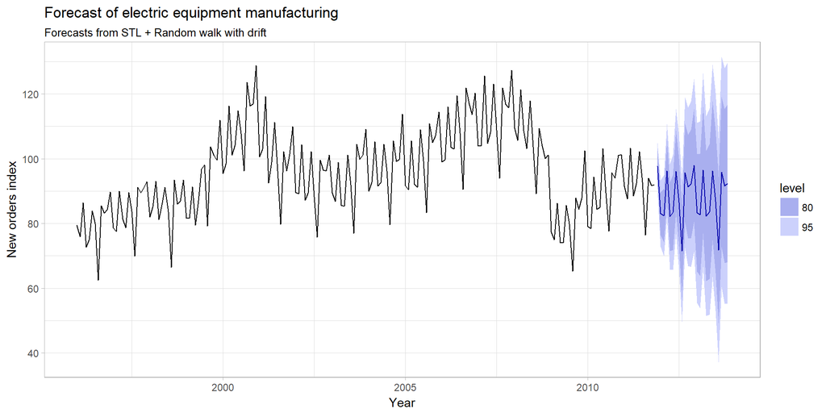

## Thank You

### Slides: https://rpubs.com/dsmilo/DATA624-Lecture

### Source code: https://github.com/dsmilo/DATA624